# Biostat 203B Homework 5

Due Mar 20 @ 11:59PM

Author

Nathaniel Boyle and 006525153

## Predicting ICU duration

Using the ICU cohort `mimiciv_icu_cohort.rds` you built in Homework 4, develop at least three machine learning approaches (logistic regression with enet regularization, random forest, boosting, SVM, MLP, etc) plus a model stacking approach for predicting whether a patient’s ICU stay will be longer than 2 days. You should use the `los_long` variable as the outcome. You algorithms can use patient demographic information (gender, age at ICU `intime`, marital status, race), ICU admission information (first care unit), the last lab measurements before the ICU stay, and first vital measurements during ICU stay as features. You are welcome to use any feature engineering techniques you think are appropriate; but make sure to not use features that are not available at an ICU stay’s `intime`. For instance, `last_careunit` cannot be used in your algorithms.

1. Data preprocessing and feature engineering.

Following slides on logistic regression

```r
# Installs
# Check if tidymodels is installed, and install if not

if (!requireNamespace("tidymodels", quietly = TRUE)) {
  install.packages("tidymodels")
}

# Check if rlang is installed, and install it if not
if (!requireNamespace("rlang", quietly = TRUE)) {
  install.packages("rlang")
}

# Check if cli is installed, and install it if not
if (!requireNamespace("cli", quietly = TRUE)) {
  install.packages("cli")
}
# Check if cli is installed, and install it if not
if (!requireNamespace("ranger", quietly = TRUE)) {
  install.packages("ranger")
}
# Check if cli is installed, and install it if not
if (!requireNamespace("keras", quietly = TRUE)) {
  install.packages("keras")
}
# Check if cli is installed, and install it if not
if (!requireNamespace("stacks", quietly = TRUE)) {
  install.packages("stacks")
}

# Load libraries
library(GGally)
library(gtsummary)
library(tidyverse)
library(tidymodels)
library(dplyr)
library(forcats)
library(gtsummary)
library(ranger)
library(keras)
library(stacks)
```

```r
version
```

```
               _
platform       x86_64-w64-mingw32
arch           x86_64
os             mingw32
crt            ucrt
system         x86_64, mingw32
status
major          4
minor          4.2
year           2024
month          10
day            31
svn rev        87279
language       R
version.string R version 4.4.2 (2024-10-31 ucrt)
nickname       Pile of Leaves
```

```r
# Load the mimic_icu_cohort data

mimiciv_icu_cohort <- readRDS("mimic_icu_cohort.rds") |>

 # Remove columns not needed for analysis
   select(-admit_provider_id, admittime, dischtime , deathtime, edregtime,
          edouttime) |>

  # Lump infrequent levels into "Other" level for specific columns
  # we take the top 5 most frequent values, rest are lumped into "other"
  mutate(first_careunit = fct_lump_n(first_careunit, n = 5,
                                     other_level = "Other"),
         last_careunit = fct_lump_n(last_careunit, n = 5,
                                    other_level = "Other"),
         admission_type = fct_lump_n(admission_type, n = 5,
                                     other_level = "Other"),
         admission_location = fct_lump_n(admission_location, n = 5,
                                         other_level = "Other"),
         discharge_location = fct_lump_n(discharge_location, n = 5,
                                         other_level = "Other"),

    #  Collapse the levels of race into specified categories
     race = fct_collapse(race,
                    ASIAN = c("ASIAN - SOUTH EAST ASIAN",
                              "ASIAN", "ASIAN - CHINESE",
                              "ASIAN - KOREAN",
                              "ASIAN - ASIAN INDIAN"),
                    BLACK = c("BLACK/AFRICAN AMERICAN",
                              "BLACK/CAPE VERDEAN",
                              "BLACK/AFRICAN",
                              "BLACK/CARIBBEAN ISLAND"),
                    HISPANIC = c("HISPANIC/LATINO - SALVADORAN",
                                 "HISPANIC/LATINO - PUERTO RICAN",
                                 "HISPANIC/LATINO - GUATEMALAN",
                                 "HISPANIC/LATINO - CUBAN",
                                 "HISPANIC/LATINO - DOMINICAN",
                                 "HISPANIC/LATINO - CENTRAL AMERICAN",
                                 "HISPANIC/LATINO - HONDURAN",
                                 "HISPANIC/LATINO - COLUMBIAN",
                                 "HISPANIC/LATINO - MEXICAN",
                                 "HISPANIC OR LATINO"),
                    WHITE = c("WHITE", "WHITE - RUSSIAN",
                              "WHITE - OTHER EUROPEAN",
                              "WHITE - BRAZILIAN",
                              "WHITE - EASTERN EUROPEAN"),
                    Other = c("OTHER", "UNKNOWN", "UNABLE TO OBTAIN",
                              "PATIENT DECLINED TO ANSWER",
                              "SOUTH AMERICAN",
                              "MULTIPLE RACE/ETHNICITY",
                              "AMERICAN INDIAN/ALASKA NATIVE",
                              "NATIVE HAWAIIAN OR OTHER PACIFIC ISLANDER")),

    # Create a new variable `los_long` based on `los`
    los_long = los >= 2
)

# create summary (stratified by los_long)
summary_table <- mimiciv_icu_cohort |>
  tbl_summary(by = c("los_long"))
```

```
7 missing rows in the "los_long" column have been removed.
```

```r
# Print the summary table
print(summary_table)
```

[output not shown]

[output cut: 762 more lines]

[output not shown]

2. Partition data into 50% training set and 50% test set. Stratify partitioning according to `los_long`. For grading purpose, sort the data by `subject_id`, `hadm_id`, and `stay_id` and use the seed `203` for the initial data split. Below is the sample code.

```r
set.seed(203)

#Sort the data by subject_id, hadm_id, and stay_id
mimiciv_icu_cohort <- mimiciv_icu_cohort |>
  arrange(subject_id, hadm_id, stay_id) |>
  select(-c(intime, outtime, admittime, dischtime, deathtime, edregtime,
            edouttime, dod, subject_id, hadm_id, stay_id, anchor_age))



# Drop rows with any NA values
mimiciv_icu_cohort <- mimiciv_icu_cohort |>
  drop_na()

# Now proceed with the rest of your analysis, such as recipe, model fitting, etc.


# Now proceed with the rest of your analysis, such as recipe, model fitting, etc.


# Perform the initial split (stratifying by los_long)
data_split <- initial_split(
  mimiciv_icu_cohort,
  strata = "los_long",
  prop = 0.1 #smaller training for faster code | change later
)
```

```r
#check training output
mimiciv_other <- training(data_split)
dim(mimiciv_other)
```

```
[1] 8406   18
```

```r
# Check for NAs in your dataset
anyNA(mimiciv_icu_cohort)
```

```
[1] FALSE
```

```r
# Get the count of missing values by column
colSums(is.na(mimiciv_icu_cohort))
```

```
      first_careunit        last_careunit                  los
                   0                    0                    0
      admission_type   admission_location   discharge_location
                   0                    0                    0
           insurance             language       marital_status
                   0                    0                    0
                race hospital_expire_flag               gender
                   0                    0                    0
         anchor_year    anchor_year_group                  age
                   0                    0                    0
      valuenum_avg_x       valuenum_avg_y             los_long
                   0                    0                    0
```

```r
#check test output
mimiciv_test <- training(data_split)
dim(mimiciv_test)
```

```
[1] 8406   18
```

```r
colSums(is.na(mimiciv_icu_cohort))
```

```
      first_careunit        last_careunit                  los
                   0                    0                    0
      admission_type   admission_location   discharge_location
                   0                    0                    0
           insurance             language       marital_status
                   0                    0                    0
                race hospital_expire_flag               gender
                   0                    0                    0
         anchor_year    anchor_year_group                  age
                   0                    0                    0
      valuenum_avg_x       valuenum_avg_y             los_long
                   0                    0                    0
```

3. Train and tune the models using the training set.

```r
# Logistic Regression recipe
logit_recipe <- recipe(
    los_long ~ .,  # Stratify on los_long
    data = mimiciv_other
  ) |>
  # Handle new levels in categorical variables (e.g., language)
  step_novel(all_nominal_predictors()) |>
  # Convert 'los_long' to factor (if it isn't already a factor)
  step_mutate(los_long = as.factor(los_long)) |>
  # Impute missing numeric values with the median
  step_impute_median(all_numeric_predictors()) |>
  # Impute missing categorical values with the mode
  step_impute_mode(all_nominal_predictors()) |>
  # Convert all categorical predictors to dummy variables
  step_dummy(all_nominal_predictors()) |>
  # Remove zero-variance predictors
  step_zv(all_numeric_predictors()) |>
  # Normalize numeric predictors
  step_normalize(all_numeric_predictors())

# Optionally, you can inspect the recipe
logit_recipe |> print()
```

```
── Recipe ──────────────────────────────────────────────────────────────────────
```

```
── Inputs
```

```
Number of variables by role
```

```
outcome:    1
predictor: 17
```

```
── Operations
```

```
• Novel factor level assignment for: all_nominal_predictors()
```

```
• Variable mutation for: as.factor(los_long)
```

```
• Median imputation for: all_numeric_predictors()
```

```
• Mode imputation for: all_nominal_predictors()
```

```
• Dummy variables from: all_nominal_predictors()
```

```
• Zero variance filter on: all_numeric_predictors()
```

```
• Centering and scaling for: all_numeric_predictors()
```

```r
# # Check if there are any remaining missing values in the dataset
 anyNA(mimiciv_other)
```

```
[1] FALSE
```

```r
 table(mimiciv_other$los_long)
```

```
FALSE  TRUE
 4282  4124
```

```r
# Logistic Regression Model

logit_mod <-
  logistic_reg(
    penalty = tune(),
    mixture = tune()
  ) |>
  set_engine("glmnet", standardize = FALSE) |>
  print()
```

```
Logistic Regression Model Specification (classification)

Main Arguments:
  penalty = tune()
  mixture = tune()

Engine-Specific Arguments:
  standardize = FALSE

Computational engine: glmnet
```

```r
#Set Logistic Workflow
logit_wf <- workflow() |>
  add_recipe(logit_recipe) |>
  add_model(logit_mod) |>
  print()
```

```
══ Workflow ════════════════════════════════════════════════════════════════════
Preprocessor: Recipe
Model: logistic_reg()

── Preprocessor ────────────────────────────────────────────────────────────────
7 Recipe Steps

• step_novel()
• step_mutate()
• step_impute_median()
• step_impute_mode()
• step_dummy()
• step_zv()
• step_normalize()

── Model ───────────────────────────────────────────────────────────────────────
Logistic Regression Model Specification (classification)

Main Arguments:
  penalty = tune()
  mixture = tune()

Engine-Specific Arguments:
  standardize = FALSE

Computational engine: glmnet
```

```r
# Create grid, tune penatly and mixure hyperparameters
param_grid <- grid_regular(
  penalty(range = c(-6, 3)),
  mixture(),
  levels = c(100, 5)
  ) |>
  print()
```

```
# A tibble: 500 × 2
      penalty mixture
        <dbl>   <dbl>
 1 0.000001         0
 2 0.00000123       0
 3 0.00000152       0
 4 0.00000187       0
 5 0.00000231       0
 6 0.00000285       0
 7 0.00000351       0
 8 0.00000433       0
 9 0.00000534       0
10 0.00000658       0
# ℹ 490 more rows
```

```r
# Cross Validation Set up
folds <- vfold_cv(mimiciv_other, v = 2)
folds
```

```
#  2-fold cross-validation
# A tibble: 2 × 2
  splits              id
  <list>              <chr>
1 <split [4203/4203]> Fold1
2 <split [4203/4203]> Fold2
```

```r
#fit cross-validation

(logit_fit <- logit_wf |>
  tune_grid(
    resamples = folds,
    grid = param_grid,
    control = control_stack_grid(), #for stacking
    metrics = metric_set(roc_auc, accuracy)
    )) |>
  system.time()
```

```
   user  system elapsed
  12.75    1.64   14.50
```

```r
logit_fit
```

```
# Tuning results
# 2-fold cross-validation
# A tibble: 2 × 5
  splits              id    .metrics             .notes           .predictions
  <list>              <chr> <list>               <list>           <list>
1 <split [4203/4203]> Fold1 <tibble [1,000 × 6]> <tibble [0 × 3]> <tibble>
2 <split [4203/4203]> Fold2 <tibble [1,000 × 6]> <tibble [0 × 3]> <tibble>
```

```
# A tibble: 1,000 × 8
      penalty mixture .metric  .estimator  mean     n  std_err
        <dbl>   <dbl> <chr>    <chr>      <dbl> <int>    <dbl>
 1 0.000001         0 accuracy binary     0.870     2 0.00654
 2 0.000001         0 roc_auc  binary     0.964     2 0.000687
 3 0.00000123       0 accuracy binary     0.870     2 0.00654
 4 0.00000123       0 roc_auc  binary     0.964     2 0.000687
 5 0.00000152       0 accuracy binary     0.870     2 0.00654
 6 0.00000152       0 roc_auc  binary     0.964     2 0.000687
 7 0.00000187       0 accuracy binary     0.870     2 0.00654
 8 0.00000187       0 roc_auc  binary     0.964     2 0.000687
 9 0.00000231       0 accuracy binary     0.870     2 0.00654
10 0.00000231       0 roc_auc  binary     0.964     2 0.000687
   .config
   <chr>
 1 Preprocessor1_Model001
 2 Preprocessor1_Model001
 3 Preprocessor1_Model002
 4 Preprocessor1_Model002
 5 Preprocessor1_Model003
 6 Preprocessor1_Model003
 7 Preprocessor1_Model004
 8 Preprocessor1_Model004
 9 Preprocessor1_Model005
10 Preprocessor1_Model005
# ℹ 990 more rows
```

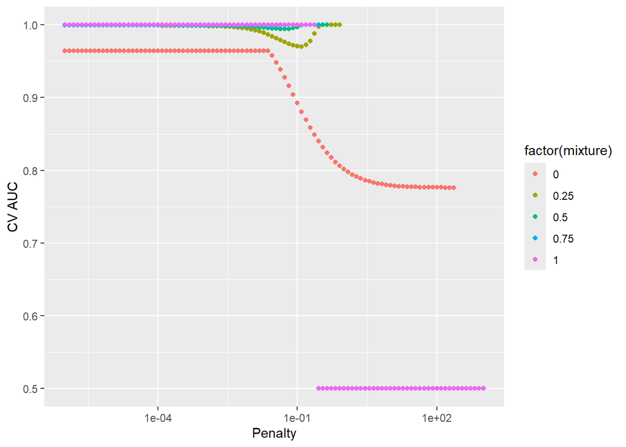

```r
#vizualize Cross Validation results

logit_fit |>
  # aggregate metrics from K folds
  collect_metrics() |>
  print(width = Inf) |>
  filter(.metric == "roc_auc") |>
  ggplot(mapping = aes(x = penalty, y = mean, color = factor(mixture))) +
  geom_point() +
  labs(x = "Penalty", y = "CV AUC") +
  scale_x_log10()
```

Show top 5 LR models

```r
logit_fit |>
  show_best(metric = "roc_auc")
```

```
# A tibble: 5 × 8
  penalty mixture .metric .estimator  mean     n std_err .config
    <dbl>   <dbl> <chr>   <chr>      <dbl> <int>   <dbl> <chr>
1   0.351    0.25 roc_auc binary         1     2       0 Preprocessor1_Model162
2   0.433    0.25 roc_auc binary         1     2       0 Preprocessor1_Model163
3   0.534    0.25 roc_auc binary         1     2       0 Preprocessor1_Model164
4   0.658    0.25 roc_auc binary         1     2       0 Preprocessor1_Model165
5   0.811    0.25 roc_auc binary         1     2       0 Preprocessor1_Model166
```

Select best model

```r
best_logit <- logit_fit |>
  select_best(metric = "roc_auc")
best_logit
```

```
# A tibble: 1 × 3
  penalty mixture .config
    <dbl>   <dbl> <chr>
1   0.351    0.25 Preprocessor1_Model162
```

Finalize LR model

```r
# Final workflow
final_wf <- logit_wf |>
  finalize_workflow(best_logit)
final_wf
```

```
══ Workflow ════════════════════════════════════════════════════════════════════
Preprocessor: Recipe
Model: logistic_reg()

── Preprocessor ────────────────────────────────────────────────────────────────
7 Recipe Steps

• step_novel()
• step_mutate()
• step_impute_median()
• step_impute_mode()
• step_dummy()
• step_zv()
• step_normalize()

── Model ───────────────────────────────────────────────────────────────────────
Logistic Regression Model Specification (classification)

Main Arguments:
  penalty = 0.351119173421513
  mixture = 0.25

Engine-Specific Arguments:
  standardize = FALSE

Computational engine: glmnet
```

Fit the whole training set, predict test cases

```r
# Fit the whole training set, then predict the test cases
final_fit <-
  final_wf |>
  last_fit(data_split)
final_fit
```

```
# Resampling results
# Manual resampling
# A tibble: 1 × 6
  splits               id              .metrics .notes   .predictions .workflow
  <list>               <chr>           <list>   <list>   <list>       <list>
1 <split [8406/75657]> train/test spl… <tibble> <tibble> <tibble>     <workflow>
```

LR Test metrics

```r
# Test metrics
final_fit |>
  collect_metrics()
```

```
# A tibble: 3 × 4
  .metric     .estimator .estimate .config
  <chr>       <chr>          <dbl> <chr>
1 accuracy    binary         0.739 Preprocessor1_Model1
2 roc_auc     binary         1     Preprocessor1_Model1
3 brier_class binary         0.218 Preprocessor1_Model1
```

We report that the Logistic regression model has an accuracy of 0.73 with an area under the ROC_AUC curve of 1.0

Training SVM Model

```r
svm_recipe <- recipe(
    los_long ~ .,  # Stratify on los_long
    data = mimiciv_other
  ) |>
  # Convert 'los_long' to factor (if it isn't already a factor)
  step_mutate(los_long = as.factor(los_long)) |>
  # Handle new levels in categorical variables (e.g., language)
  step_novel(all_nominal_predictors()) |>
  # Impute missing values for numeric columns (mean imputation)
  step_impute_mean(all_numeric_predictors()) |>
  # Impute missing values for categorical/logical columns (mode imputation)
  step_impute_mode(all_nominal_predictors()) |>
  step_unknown(all_nominal_predictors()) |>
  # Create dummy variables for nominal predictors
  step_dummy(all_nominal_predictors()) |>
  # Zero-variance filter for numeric predictors
  step_zv(all_numeric_predictors()) |>
  # Normalize numeric predictors
  step_normalize(all_numeric_predictors())|>
  print()
```

```
── Recipe ──────────────────────────────────────────────────────────────────────
```

```
── Inputs
```

```
Number of variables by role
```

```
outcome:    1
predictor: 17
```

```
── Operations
```

```
• Variable mutation for: as.factor(los_long)
```

```
• Novel factor level assignment for: all_nominal_predictors()
```

```
• Mean imputation for: all_numeric_predictors()
```

```
• Mode imputation for: all_nominal_predictors()
```

```
• Unknown factor level assignment for: all_nominal_predictors()
```

```
• Dummy variables from: all_nominal_predictors()
```

```
• Zero variance filter on: all_numeric_predictors()
```

```
• Centering and scaling for: all_numeric_predictors()
```

```r
#SVM model classification
svm_mod <-
  svm_rbf(
    mode = "classification",
    cost = tune(),
    rbf_sigma = tune()
  ) |>
  set_engine("kernlab")
svm_mod
```

```
Radial Basis Function Support Vector Machine Model Specification (classification)

Main Arguments:
  cost = tune()
  rbf_sigma = tune()

Computational engine: kernlab
```

SVM workflow

```r
svm_wf <- workflow() |>
  add_recipe(svm_recipe) |>
  add_model(svm_mod)
svm_wf
```

```
══ Workflow ════════════════════════════════════════════════════════════════════
Preprocessor: Recipe
Model: svm_rbf()

── Preprocessor ────────────────────────────────────────────────────────────────
8 Recipe Steps

• step_mutate()
• step_novel()
• step_impute_mean()
• step_impute_mode()
• step_unknown()
• step_dummy()
• step_zv()
• step_normalize()

── Model ───────────────────────────────────────────────────────────────────────
Radial Basis Function Support Vector Machine Model Specification (classification)

Main Arguments:
  cost = tune()
  rbf_sigma = tune()

Computational engine: kernlab
```

SVM Tuning Grid

```r
param_grid <- grid_regular(
  cost(range = c(-8, 5)),
  rbf_sigma(range = c(-5, -3)),
  levels = c(14, 5)
  )
param_grid
```

```
# A tibble: 70 × 2
      cost rbf_sigma
     <dbl>     <dbl>
 1 0.00391   0.00001
 2 0.00781   0.00001
 3 0.0156    0.00001
 4 0.0312    0.00001
 5 0.0625    0.00001
 6 0.125     0.00001
 7 0.25      0.00001
 8 0.5       0.00001
 9 1         0.00001
10 2         0.00001
# ℹ 60 more rows
```

Cross-Validation

```r
#install.packages("kernlab")
set.seed(203)

folds <- vfold_cv(mimiciv_other, v = 2)
folds
```

```
#  2-fold cross-validation
# A tibble: 2 × 2
  splits              id
  <list>              <chr>
1 <split [4203/4203]> Fold1
2 <split [4203/4203]> Fold2
```

```r
#fit svm
svm_fit <- svm_wf |>
  tune_grid(
    resamples = folds,
    grid = param_grid,
    control = control_stack_grid(), #for stacking
    metrics = metric_set(roc_auc, accuracy)
    )
svm_fit
```

```
# Tuning results
# 2-fold cross-validation
# A tibble: 2 × 5
  splits              id    .metrics           .notes           .predictions
  <list>              <chr> <list>             <list>           <list>
1 <split [4203/4203]> Fold1 <tibble [140 × 6]> <tibble [0 × 3]> <tibble>
2 <split [4203/4203]> Fold2 <tibble [140 × 6]> <tibble [0 × 3]> <tibble>
```

```
# A tibble: 140 × 8
      cost rbf_sigma .metric  .estimator  mean     n std_err
     <dbl>     <dbl> <chr>    <chr>      <dbl> <int>   <dbl>
 1 0.00391   0.00001 accuracy binary     0.509     2 0.00309
 2 0.00391   0.00001 roc_auc  binary     0.786     2 0.00484
 3 0.00781   0.00001 accuracy binary     0.509     2 0.00309
 4 0.00781   0.00001 roc_auc  binary     0.790     2 0.00424
 5 0.0156    0.00001 accuracy binary     0.509     2 0.00309
 6 0.0156    0.00001 roc_auc  binary     0.793     2 0.00574
 7 0.0312    0.00001 accuracy binary     0.509     2 0.00309
 8 0.0312    0.00001 roc_auc  binary     0.793     2 0.00573
 9 0.0625    0.00001 accuracy binary     0.509     2 0.00309
10 0.0625    0.00001 roc_auc  binary     0.794     2 0.00575
   .config
   <chr>
 1 Preprocessor1_Model01
 2 Preprocessor1_Model01
 3 Preprocessor1_Model02
 4 Preprocessor1_Model02
 5 Preprocessor1_Model03
 6 Preprocessor1_Model03
 7 Preprocessor1_Model04
 8 Preprocessor1_Model04
 9 Preprocessor1_Model05
10 Preprocessor1_Model05
# ℹ 130 more rows
```

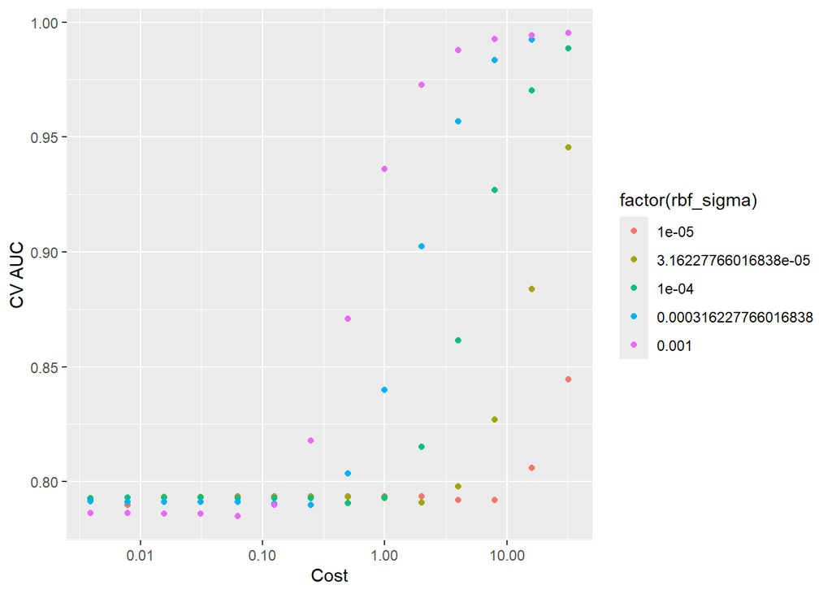

```r
svm_fit |>
  collect_metrics() |>
  print(width = Inf) |>
  filter(.metric == "roc_auc") |>
  ggplot(mapping = aes(x = cost, y = mean, color = factor(rbf_sigma))) +
  geom_point() +
  labs(x = "Cost", y = "CV AUC") +
  scale_x_log10()
```

```r
svm_fit |>
  show_best(metric = "roc_auc")
```

```
# A tibble: 5 × 8
   cost rbf_sigma .metric .estimator  mean     n   std_err .config
  <dbl>     <dbl> <chr>   <chr>      <dbl> <int>     <dbl> <chr>
1    32  0.001    roc_auc binary     0.995     2 0.000261  Preprocessor1_Model70
2    32  0.000316 roc_auc binary     0.995     2 0.000479  Preprocessor1_Model56
3    16  0.001    roc_auc binary     0.994     2 0.0000385 Preprocessor1_Model69
4     8  0.001    roc_auc binary     0.993     2 0.000475  Preprocessor1_Model68
5    16  0.000316 roc_auc binary     0.992     2 0.00114   Preprocessor1_Model55
```

```r
#select best model
best_svm <- svm_fit |>
  select_best(metric = "roc_auc")
best_svm
```

```
# A tibble: 1 × 3
   cost rbf_sigma .config
  <dbl>     <dbl> <chr>
1    32     0.001 Preprocessor1_Model70
```

Finalize SVM model

```r
final_wf <- svm_wf |>
  finalize_workflow(best_svm)
final_wf
```

```
══ Workflow ════════════════════════════════════════════════════════════════════
Preprocessor: Recipe
Model: svm_rbf()

── Preprocessor ────────────────────────────────────────────────────────────────
8 Recipe Steps

• step_mutate()
• step_novel()
• step_impute_mean()
• step_impute_mode()
• step_unknown()
• step_dummy()
• step_zv()
• step_normalize()

── Model ───────────────────────────────────────────────────────────────────────
Radial Basis Function Support Vector Machine Model Specification (classification)

Main Arguments:
  cost = 32
  rbf_sigma = 0.001

Computational engine: kernlab
```

```r
# Fit the whole training set, then predict the test cases
final_fit <-
  final_wf |>
  last_fit(data_split)
final_fit
```

```
# Resampling results
# Manual resampling
# A tibble: 1 × 6
  splits               id              .metrics .notes   .predictions .workflow
  <list>               <chr>           <list>   <list>   <list>       <list>
1 <split [8406/75657]> train/test spl… <tibble> <tibble> <tibble>     <workflow>
```

SVM test metrics

```r
# Test metrics
final_fit |>
  collect_metrics()
```

```
# A tibble: 3 × 4
  .metric     .estimator .estimate .config
  <chr>       <chr>          <dbl> <chr>
1 accuracy    binary        0.961  Preprocessor1_Model1
2 roc_auc     binary        0.997  Preprocessor1_Model1
3 brier_class binary        0.0216 Preprocessor1_Model1
```

For the SVM model we report an area under the roc_ curve of 0.99 with an accuracy of 96%

Train Random Forest Model

```r
rf_recipe <- recipe(
    los_long ~ .,  # Stratify on los_long
    data = mimiciv_other
  ) |>
  # Convert 'los_long' to factor (if it isn't already a factor)
  step_mutate(los_long = as.factor(los_long)) |>
  # Handle new levels in categorical variables (e.g., language)
  step_novel(all_nominal_predictors()) |>
  # Impute missing values for numeric columns (mean imputation)
  step_impute_mean(all_numeric_predictors()) |>
  # Impute missing values for categorical/logical columns (mode imputation)
  step_impute_mode(all_nominal_predictors()) |>
  step_unknown(all_nominal_predictors()) |>
  # Create dummy variables for nominal predictors
  step_dummy(all_nominal_predictors()) |>
  # Zero-variance filter for numeric predictors
  step_zv(all_numeric_predictors()) |>
  # Normalize numeric predictors
  step_normalize(all_numeric_predictors())|>
  print()
```

```
── Recipe ──────────────────────────────────────────────────────────────────────
```

```
── Inputs
```

```
Number of variables by role
```

```
outcome:    1
predictor: 17
```

```
── Operations
```

```
• Variable mutation for: as.factor(los_long)
```

```
• Novel factor level assignment for: all_nominal_predictors()
```

```
• Mean imputation for: all_numeric_predictors()
```

```
• Mode imputation for: all_nominal_predictors()
```

```
• Unknown factor level assignment for: all_nominal_predictors()
```

```
• Dummy variables from: all_nominal_predictors()
```

```
• Zero variance filter on: all_numeric_predictors()
```

```
• Centering and scaling for: all_numeric_predictors()
```

```r
rf_mod <-
  rand_forest(
    mode = "classification",
    # Number of predictors randomly sampled in each split
    mtry = tune(),
    # Number of trees in ensemble
    trees = tune()
  ) |>
  set_engine("ranger")
rf_mod
```

```
Random Forest Model Specification (classification)

Main Arguments:
  mtry = tune()
  trees = tune()

Computational engine: ranger
```

```r
rf_wf <- workflow() |>
  add_recipe(rf_recipe) |>
  add_model(rf_mod)
rf_wf
```

```
══ Workflow ════════════════════════════════════════════════════════════════════
Preprocessor: Recipe
Model: rand_forest()

── Preprocessor ────────────────────────────────────────────────────────────────
8 Recipe Steps

• step_mutate()
• step_novel()
• step_impute_mean()
• step_impute_mode()
• step_unknown()
• step_dummy()
• step_zv()
• step_normalize()

── Model ───────────────────────────────────────────────────────────────────────
Random Forest Model Specification (classification)

Main Arguments:
  mtry = tune()
  trees = tune()

Computational engine: ranger
```

```r
#set grid
param_grid <- grid_regular(
  trees(range = c(100L, 500L)),
  mtry(range = c(1L, 5L)),
  levels = c(5, 5)
  )
param_grid
```

```
# A tibble: 25 × 2
   trees  mtry
   <int> <int>
 1   100     1
 2   200     1
 3   300     1
 4   400     1
 5   500     1
 6   100     2
 7   200     2
 8   300     2
 9   400     2
10   500     2
# ℹ 15 more rows
```

```r
#set folds
set.seed(203)

folds <- vfold_cv(mimiciv_other, v = 2)
folds
```

```
#  2-fold cross-validation
# A tibble: 2 × 2
  splits              id
  <list>              <chr>
1 <split [4203/4203]> Fold1
2 <split [4203/4203]> Fold2
```

```r
#fit random forest model
rf_fit <- rf_wf |>
  tune_grid(
    resamples = folds,
    grid = param_grid,
    control = control_stack_grid(), #for stacking
    metrics = metric_set(roc_auc, accuracy)
    )
rf_fit
```

```
# Tuning results
# 2-fold cross-validation
# A tibble: 2 × 5
  splits              id    .metrics          .notes           .predictions
  <list>              <chr> <list>            <list>           <list>
1 <split [4203/4203]> Fold1 <tibble [50 × 6]> <tibble [0 × 3]> <tibble>
2 <split [4203/4203]> Fold2 <tibble [50 × 6]> <tibble [0 × 3]> <tibble>
```

```
# A tibble: 50 × 8
    mtry trees .metric  .estimator  mean     n    std_err .config
   <int> <int> <chr>    <chr>      <dbl> <int>      <dbl> <chr>
 1     1   100 accuracy binary     0.966     2 0.0236     Preprocessor1_Model01
 2     1   100 roc_auc  binary     0.996     2 0.00320    Preprocessor1_Model01
 3     1   200 accuracy binary     0.985     2 0.00845    Preprocessor1_Model02
 4     1   200 roc_auc  binary     1.00      2 0.0000397  Preprocessor1_Model02
 5     1   300 accuracy binary     0.960     2 0.00857    Preprocessor1_Model03
 6     1   300 roc_auc  binary     0.996     2 0.000415   Preprocessor1_Model03
 7     1   400 accuracy binary     0.982     2 0.00119    Preprocessor1_Model04
 8     1   400 roc_auc  binary     0.999     2 0.000490   Preprocessor1_Model04
 9     1   500 accuracy binary     0.989     2 0.00500    Preprocessor1_Model05
10     1   500 roc_auc  binary     1.00      2 0.00000594 Preprocessor1_Model05
# ℹ 40 more rows
```

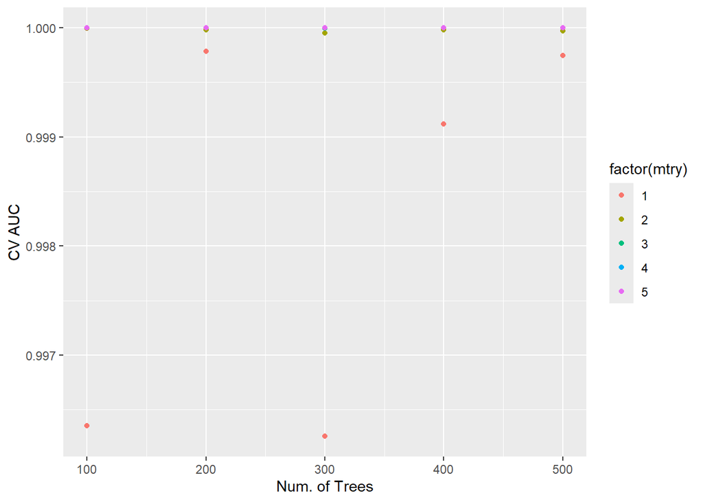

```r
rf_fit |>
  collect_metrics() |>
  print(width = Inf) |>
  filter(.metric == "roc_auc") |>
  ggplot(mapping = aes(x = trees, y = mean, color = factor(mtry))) +
  geom_point() +
  # geom_line() +
  labs(x = "Num. of Trees", y = "CV AUC")
```

Shoow top 5 models

```r
rf_fit |>
  show_best(metric = "roc_auc")
```

```
# A tibble: 5 × 8
   mtry trees .metric .estimator  mean     n     std_err .config
  <int> <int> <chr>   <chr>      <dbl> <int>       <dbl> <chr>
1     4   200 roc_auc binary      1.00     2 0.000000227 Preprocessor1_Model17
2     4   300 roc_auc binary      1.00     2 0.000000227 Preprocessor1_Model18
3     4   400 roc_auc binary      1.00     2 0.000000227 Preprocessor1_Model19
4     4   500 roc_auc binary      1.00     2 0.000000227 Preprocessor1_Model20
5     5   100 roc_auc binary      1.00     2 0.000000227 Preprocessor1_Model21
```

Choose best model

```r
best_rf <- rf_fit |>
  select_best(metric = "roc_auc")
best_rf
```

```
# A tibble: 1 × 3
   mtry trees .config
  <int> <int> <chr>
1     4   200 Preprocessor1_Model17
```

Finalize RF model

```r
# Final workflow
final_wf <- rf_wf |>
  finalize_workflow(best_rf)
final_wf
```

```
══ Workflow ════════════════════════════════════════════════════════════════════
Preprocessor: Recipe
Model: rand_forest()

── Preprocessor ────────────────────────────────────────────────────────────────
8 Recipe Steps

• step_mutate()
• step_novel()
• step_impute_mean()
• step_impute_mode()
• step_unknown()
• step_dummy()
• step_zv()
• step_normalize()

── Model ───────────────────────────────────────────────────────────────────────
Random Forest Model Specification (classification)

Main Arguments:
  mtry = 4
  trees = 200

Computational engine: ranger
```

```r
# Fit the whole training set, then predict the test cases
final_fit <-
  final_wf |>
  last_fit(data_split)
final_fit
```

```
# Resampling results
# Manual resampling
# A tibble: 1 × 6
  splits               id              .metrics .notes   .predictions .workflow
  <list>               <chr>           <list>   <list>   <list>       <list>
1 <split [8406/75657]> train/test spl… <tibble> <tibble> <tibble>     <workflow>
```

```r
# Test metrics
final_fit |>
  collect_metrics()
```

```
# A tibble: 3 × 4
  .metric     .estimator .estimate .config
  <chr>       <chr>          <dbl> <chr>
1 accuracy    binary        1.00   Preprocessor1_Model1
2 roc_auc     binary        1.00   Preprocessor1_Model1
3 brier_class binary        0.0465 Preprocessor1_Model1
```

The RF model has the highest accuracy of 99% and an area under the ROC AUC curve of 1.

Stacking the models

Shared recipe

```r
stacked_recipe <-
  recipe(
    los_long ~ .,
    data = mimiciv_other
  ) |>
  # Convert 'los_long' to factor (if it isn't already a factor)
  step_mutate(los_long = as.factor(los_long)) |>
  # Handle new levels in categorical variables (e.g., language)
  step_novel(all_nominal_predictors()) |>
  # Impute missing values for numeric columns (mean imputation)
  step_impute_mean(all_numeric_predictors()) |>
  # Impute missing values for categorical/logical columns (mode imputation)
  step_impute_mode(all_nominal_predictors()) |>
  step_unknown(all_nominal_predictors()) |>
  # Create dummy variables for nominal predictors
  step_dummy(all_nominal_predictors()) |>
  # Zero-variance filter for numeric predictors
  step_zv(all_numeric_predictors()) |>
  # Normalize numeric predictors
  step_normalize(all_numeric_predictors())
stacked_recipe
```

```
── Recipe ──────────────────────────────────────────────────────────────────────
```

```
── Inputs
```

```
Number of variables by role
```

```
outcome:    1
predictor: 17
```

```
── Operations
```

```
• Variable mutation for: as.factor(los_long)
```

```
• Novel factor level assignment for: all_nominal_predictors()
```

```
• Mean imputation for: all_numeric_predictors()
```

```
• Mode imputation for: all_nominal_predictors()
```

```
• Unknown factor level assignment for: all_nominal_predictors()
```

```
• Dummy variables from: all_nominal_predictors()
```

```
• Zero variance filter on: all_numeric_predictors()
```

```
• Centering and scaling for: all_numeric_predictors()
```

Logistic Regression Model

```r
logit_mod <-
  logistic_reg(
    penalty = tune(),
    mixture = tune()
  ) |>
  set_engine("glmnet", standardize = TRUE)
logit_mod
```

```
Logistic Regression Model Specification (classification)

Main Arguments:
  penalty = tune()
  mixture = tune()

Engine-Specific Arguments:
  standardize = TRUE

Computational engine: glmnet
```

```r
logit_wf <- workflow() |>
  add_recipe(stacked_recipe) |>
  add_model(logit_mod)
logit_wf
```

```
══ Workflow ════════════════════════════════════════════════════════════════════
Preprocessor: Recipe
Model: logistic_reg()

── Preprocessor ────────────────────────────────────────────────────────────────
8 Recipe Steps

• step_mutate()
• step_novel()
• step_impute_mean()
• step_impute_mode()
• step_unknown()
• step_dummy()
• step_zv()
• step_normalize()

── Model ───────────────────────────────────────────────────────────────────────
Logistic Regression Model Specification (classification)

Main Arguments:
  penalty = tune()
  mixture = tune()

Engine-Specific Arguments:
  standardize = TRUE

Computational engine: glmnet
```

```r
logit_grid <- grid_regular(
  penalty(range = c(-6, 3)),
  mixture(),
  levels = c(100, 5)
  )

logit_res <-
  tune_grid(
    object = logit_wf,
    resamples = folds,
    grid = logit_grid,
    control = control_stack_grid()
  )
logit_res
```

```
# Tuning results
# 2-fold cross-validation
# A tibble: 2 × 5
  splits              id    .metrics             .notes           .predictions
  <list>              <chr> <list>               <list>           <list>
1 <split [4203/4203]> Fold1 <tibble [1,500 × 6]> <tibble [0 × 3]> <tibble>
2 <split [4203/4203]> Fold2 <tibble [1,500 × 6]> <tibble [0 × 3]> <tibble>
```

Random Forest Model

```r
rf_mod <-
  rand_forest(
    mode = "classification",
    # Number of predictors randomly sampled in each split
    mtry = tune(),
    # Number of trees in ensemble
    trees = tune()
  ) |>
  set_engine("ranger")
rf_mod
```

```
Random Forest Model Specification (classification)

Main Arguments:
  mtry = tune()
  trees = tune()

Computational engine: ranger
```

```r
rf_wf <- workflow() |>
  add_recipe(stacked_recipe) |>
  add_model(rf_mod)
rf_wf
```

```
══ Workflow ════════════════════════════════════════════════════════════════════
Preprocessor: Recipe
Model: rand_forest()

── Preprocessor ────────────────────────────────────────────────────────────────
8 Recipe Steps

• step_mutate()
• step_novel()
• step_impute_mean()
• step_impute_mode()
• step_unknown()
• step_dummy()
• step_zv()
• step_normalize()

── Model ───────────────────────────────────────────────────────────────────────
Random Forest Model Specification (classification)

Main Arguments:
  mtry = tune()
  trees = tune()

Computational engine: ranger
```

```r
rf_grid <- grid_regular(
  trees(range = c(100L, 500L)),
  mtry(range = c(1L, 5L)),
  levels = c(5, 5)
  )

rf_res <-
  tune_grid(
    object = rf_wf,
    resamples = folds,
    grid = rf_grid,
    control = control_stack_grid()
  )
rf_res
```

```
# Tuning results
# 2-fold cross-validation
# A tibble: 2 × 5
  splits              id    .metrics          .notes           .predictions
  <list>              <chr> <list>            <list>           <list>
1 <split [4203/4203]> Fold1 <tibble [75 × 6]> <tibble [0 × 3]> <tibble>
2 <split [4203/4203]> Fold2 <tibble [75 × 6]> <tibble [0 × 3]> <tibble>
```

Stack Logistic Regression and Randomforest

```r
stack_model <-
  # initialize the stack
  stacks() |>
  # add candidate members (fits)
  add_candidates(logit_res) |>
  add_candidates(rf_res) |>
  #add_candidates(mlp_res) |>
  # determine how to combine their predictions
  blend_predictions(
    penalty = 10^(-6:2),
    metrics = c("roc_auc")
    ) |>
  # fit the candidates with nonzero stacking coefficients
  fit_members()
```

Plot statistics of stack models.

```r
stack_model
```

```
── A stacked ensemble model ─────────────────────────────────────


Out of 251 possible candidate members, the ensemble retained 7.

Penalty: 1e-06.

Mixture: 1.


The 7 highest weighted member classes are:
```

```
# A tibble: 7 × 3
  member                     type           weight
  <chr>                      <chr>           <dbl>
1 .pred_TRUE_rf_res_1_21     rand_forest  15.7
2 .pred_TRUE_rf_res_1_24     rand_forest   6.35
3 .pred_TRUE_logit_res_1_401 logistic_reg  2.10
4 .pred_TRUE_rf_res_1_22     rand_forest   0.875
5 .pred_TRUE_logit_res_1_417 logistic_reg  0.0246
6 .pred_TRUE_logit_res_1_418 logistic_reg  0.00920
7 .pred_TRUE_logit_res_1_419 logistic_reg  0.00177
```

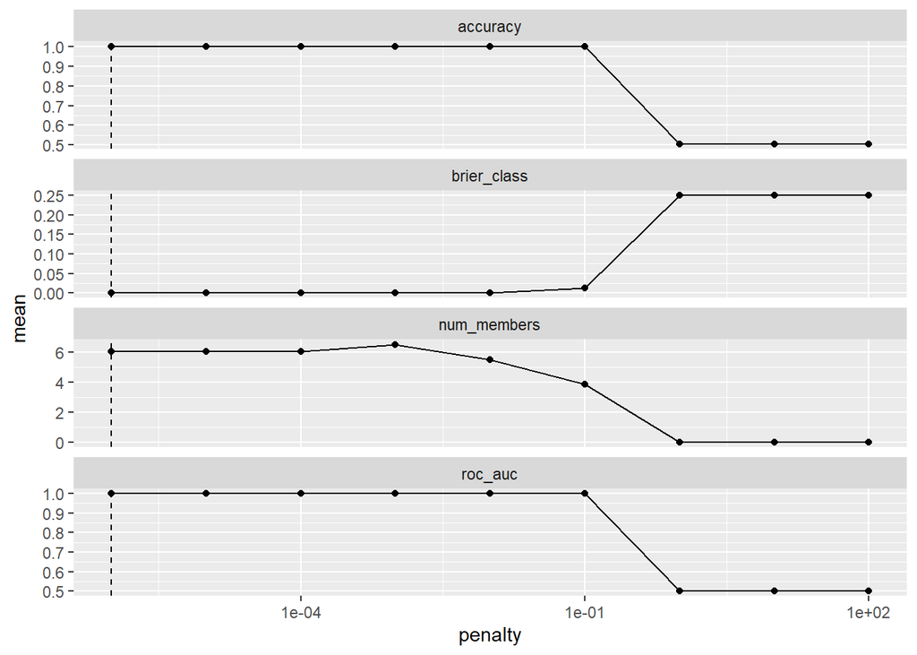

```r
autoplot(stack_model)
```

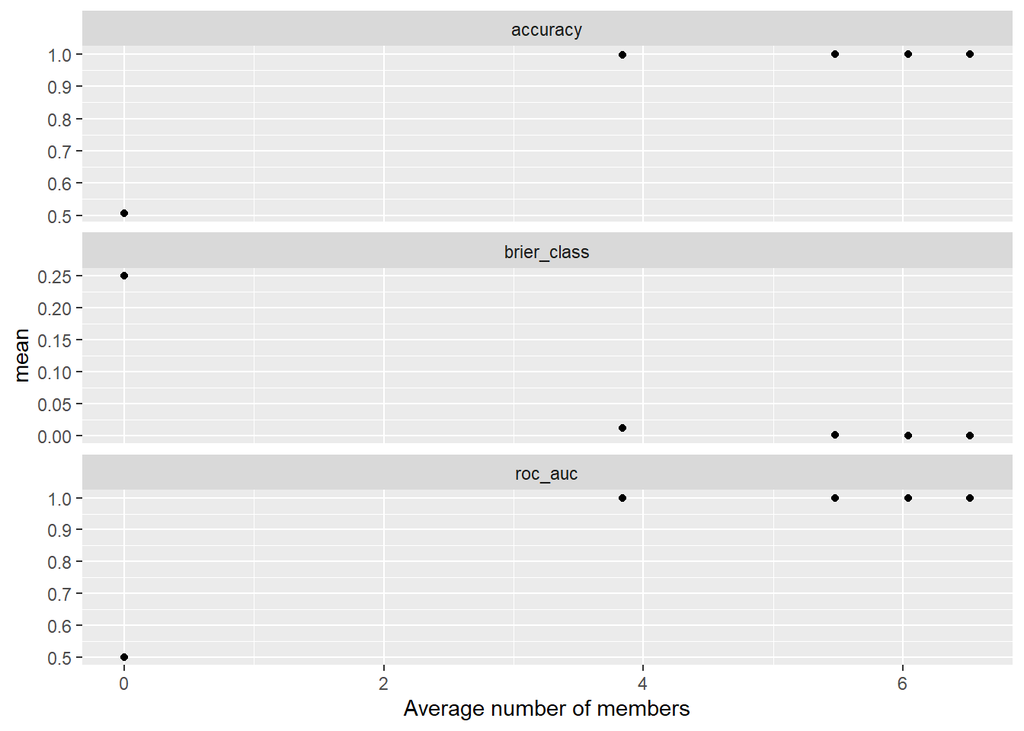

```r
autoplot(stack_model, type = "members")
```

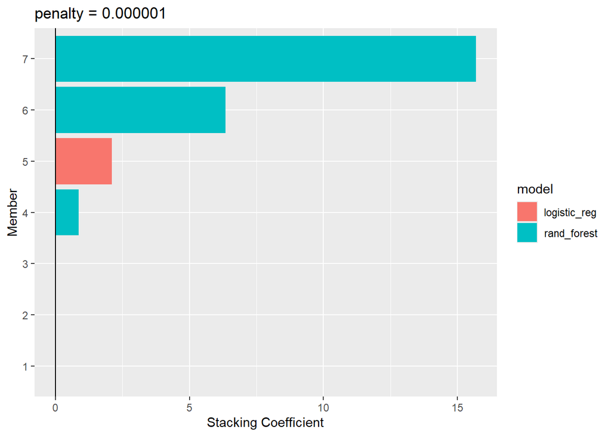

```r
autoplot(stack_model, type = "weights")
```

```r
collect_parameters(stack_model, "rf_res")
```

```
# A tibble: 25 × 5
   member       mtry trees terms                   coef
   <chr>       <int> <int> <chr>                  <dbl>
 1 rf_res_1_01     1   100 .pred_TRUE_rf_res_1_01     0
 2 rf_res_1_02     1   200 .pred_TRUE_rf_res_1_02     0
 3 rf_res_1_03     1   300 .pred_TRUE_rf_res_1_03     0
 4 rf_res_1_04     1   400 .pred_TRUE_rf_res_1_04     0
 5 rf_res_1_05     1   500 .pred_TRUE_rf_res_1_05     0
 6 rf_res_1_06     2   100 .pred_TRUE_rf_res_1_06     0
 7 rf_res_1_07     2   200 .pred_TRUE_rf_res_1_07     0
 8 rf_res_1_08     2   300 .pred_TRUE_rf_res_1_08     0
 9 rf_res_1_09     2   400 .pred_TRUE_rf_res_1_09     0
10 rf_res_1_10     2   500 .pred_TRUE_rf_res_1_10     0
# ℹ 15 more rows
```

4. Compare model classification performance on the test set. Report both the area under ROC curve and accuracy for each machine learning algorithm and the model stacking. Interpret the results.

What are the most important features in predicting long ICU stays? How do the models compare in terms of performance and interpretability?

The SVM model took by far the longest to train and to evauate, estimating about 30 minutes of run time. The logistic regression model was by far the fastest and also had the best interpretability.